# DeepMLP Project

**Colab Link** : https://colab.research.google.com/drive/1dMdK83nLCLB1YvU8v1dy45U4nZ_Ki48o?usp=sharing

**Objective:** Train and evaluate a deep MLP classifier on FashionMNIST.  
**Key outputs:** (i) train + validation loss curves, (ii) validation error, (iii) brief discussion of overfitting + improvements.

## 1. Setup

- Device: `mps` (Apple Silicon GPU)
- Libraries: PyTorch, torchvision, matplotlib

## 2. Data

- Dataset: FashionMNIST (28×28 grayscale, 10 classes)
- Split: train/validation

## 3. Model

- Architecture: Deep MLP
- Regularisation variants: dropout, weight decay, BatchNorm

## 4. Training

- Loss: Cross entropy
- Optimiser: AdamW
- Model selection: validation metrics / early stopping analysis

## 5. Results

- Validation accuracy / error (reported below from notebook outputs)
- Figures: loss curves + accuracy curves

## 6. Initial Observations (Baseline Model)

- Baseline performance summary
- Generalisation gap / overfitting evidence

## 7. Model Variants (Motivated Experiments)

- Regularisation and optimisation sweeps
- Early stopping + final improvements

## 1. Setup

### 1.1 Imports

```python
import torch
import torch.nn as nn
import matplotlib.pyplot as plt
from torchvision import datasets, transforms
from torch.utils.data import DataLoader
import torch.optim as optim
import time
```

### 1.2 Device Setup

```python
# Device setup:
# Prefer CUDA if running on an NVIDIA GPU, however I'm using my own IDE and don't have access to CUDA, so I will use MPS if available, otherwise CPU.
if torch.cuda.is_available():
    device = torch.device("cuda")
elif hasattr(torch.backends, "mps") and torch.backends.mps.is_available():
    device = torch.device("mps")   # Apple Silicon GPU
else:
    device = torch.device("cpu")
# Fallback to CPU if no GPU backend is available.
print("Device:", device)
```

```
Device: mps
```

> **Note:** I’m using `mps` (Apple Silicon GPU). Results may differ slightly from CPU/CUDA. In this case, device prints mps and so that means Apple GPU backend (Metal), so training runs on the Mac’s GPU rather than CPU (often faster for batches, though not always as fast as CUDA for deep nets).

## 2. Data (FashionMNIST)

This notebook loads the **FashionMNIST** dataset (28×28 grayscale, 10 classes):

- download + `ToTensor()` transform
- convert to `list(...)` so we can slice (simple + deterministic)
- create `train` / `val` subsets via slicing

For the summative, we then scale up to use (almost) the full dataset once the pipeline works.

```python
# Reproducibility (keeps train/val split consistent across runs)
# We seed Python, NumPy and PyTorch RNGs so operations that use these RNGs are repeatable.
# Note: this reduces run-to-run variability but does not guarantee bitwise identical results
# across different hardware or PyTorch versions (MPS/CUDA kernels can still be nondeterministic).
import random
import numpy as np

seed = 42
random.seed(seed)                # Python `random` module
np.random.seed(seed)             # NumPy RNG
torch.manual_seed(seed)          # PyTorch CPU / default RNG (affects weight init etc.)
if torch.cuda.is_available():
    # Seed all CUDA devices (if using CUDA)
    torch.cuda.manual_seed_all(seed)

# Request deterministic algorithms when available. This may slow training and some
# backends (especially MPS) may not fully support deterministic modes; we ignore
# failures so the notebook still runs if the backend doesn't support it.
try:
    torch.use_deterministic_algorithms(True)
except Exception:
    pass
# Disable the CuDNN autotuner which can introduce nondeterminism
torch.backends.cudnn.benchmark = False

# Generator to use for DataLoader shuffling (ensures repeatable shuffle order)
# Use this with DataLoader(..., shuffle=True, generator=g, num_workers=0)
g = torch.Generator()
g.manual_seed(seed)

print("Seeds set. Device:", device)
```

```
Seeds set. Device: mps
```

### 2.1 Load dataset

Transform: `ToTensor()` converts PIL images to tensors of shape `(1, 28, 28)` and rescales pixels to `[0, 1]`.

```python
data_dir = "./data"

transform = transforms.ToTensor()

fashion_train_full = datasets.FashionMNIST(
    root=data_dir,
    train=True,
    download=True,
    transform=transform,
)

fashion_test = datasets.FashionMNIST(
    root=data_dir,
    train=False,
    download=True,
    transform=transform,
)

print("Train full:", len(fashion_train_full))
print("Test:", len(fashion_test))
```

```
Train full: 60000
Test: 10000
```

### 2.2 Train/validation split (notebook-style slicing)

We convert the training dataset to a list so we can slice it.  
We use a toggle:

- `QUICK_MODE=True` → small subset for fast iteration (debugging / hyperparameter search)
- `QUICK_MODE=False` → scale up to (almost) the full dataset for final results

```python
# Convert to list so slicing works
fashion_data = list(fashion_train_full)

QUICK_MODE = False  # set False for final training/reporting

if QUICK_MODE:
    # Fast iteration: use a smaller training set (but keep a reasonably sized validation set)
    n_train = 12000
    n_val = 2000
else:
    # Final run: use almost all available training data
    # (keep a reasonably sized validation set)
    n_val = 10000
    n_train = len(fashion_data) - n_val  # 50,000 train

fashion_train = fashion_data[:n_train]
fashion_val   = fashion_data[n_train:n_train + n_val]

print("Using Train:", len(fashion_train))
print("Using Val:", len(fashion_val))
```

```
Using Train: 50000
Using Val: 10000
```

### 2.3 Debug subset

A tiny subset is useful to quickly verify the training loop works (loss decreases, shape is fine, device is fine).

```python
debug_data = fashion_train[:64]
print("Debug subset size:", len(debug_data))
```

```
Debug subset size: 64
```

### 2.4 Visual sanity check

Plot a few images to confirm the data pipeline is correct.

[figure not shown]

```python
import matplotlib.pyplot as plt

# Take a few samples directly from the train list (no DataLoader here, matching notebook style)
plt.figure(figsize=(8, 3))
for i in range(10):
    img, label = fashion_train[i]
    plt.subplot(2, 5, i + 1)
    plt.imshow(img.squeeze(0), cmap="gray")
    plt.title(int(label))
    plt.axis("off")

plt.tight_layout()
plt.show()
```

## 3. Model (Deep MLP)

We build a **deep multi-layer perceptron (MLP)** for FashionMNIST classification.

Notes:

- Input images are `(1, 28, 28)` so we **flatten** to a vector of length `784`.
- Output layer has **10 logits** (one per class).
- We do **not** apply softmax in the model because `CrossEntropyLoss` expects raw logits.

```python
import torch.nn as nn

class DeepMLP(nn.Module):
    def __init__(self):
        super().__init__()

        # Sequential stack
        self.net = nn.Sequential(
            nn.Flatten(),                 # (B, 1, 28, 28) -> (B, 784)

            nn.Linear(28*28, 512),
            nn.ReLU(),

            nn.Linear(512, 256),
            nn.ReLU(),

            nn.Linear(256, 128),
            nn.ReLU(),

            nn.Linear(128, 10)            # logits for 10 classes
        )

    def forward(self, x):
        return self.net(x)
```

### 3.1 Instantiate model + sanity check output shape

```python
model = DeepMLP().to(device)
print(model)

# Quick forward pass to confirm shapes
x0, y0 = fashion_train[0]           # one example from the train list
x0 = x0.unsqueeze(0).to(device)    # add batch dimension: (1, 1, 28, 28)

out0 = model(x0)
print("Input shape:", x0.shape)
print("Output shape:", out0.shape)  # expected: (1, 10)
```

```
DeepMLP(
  (net): Sequential(
    (0): Flatten(start_dim=1, end_dim=-1)
    (1): Linear(in_features=784, out_features=512, bias=True)
    (2): ReLU()
    (3): Linear(in_features=512, out_features=256, bias=True)
    (4): ReLU()
    (5): Linear(in_features=256, out_features=128, bias=True)
    (6): ReLU()
    (7): Linear(in_features=128, out_features=10, bias=True)
  )
)
Input shape: torch.Size([1, 1, 28, 28])
Output shape: torch.Size([1, 10])
```

### 3.2 Parameter count

Useful to report model size / complexity.

```python
num_params = sum(p.numel() for p in model.parameters() if p.requires_grad)
print("Trainable parameters:", num_params)
```

```
Trainable parameters: 567434
```

## 4. Training & Evaluation

We train the MLP using **cross-entropy loss** and an optimiser (Adam/AdamW).  
We then do the following:

- write helper functions (accuracy)
- write a `train(...)` function that creates its own `DataLoader`
- record **train + validation loss per epoch**

### 4.1 Accuracy function

This evaluates accuracy on a dataset/list by creating a `DataLoader` internally. We use `model.eval()` and `torch.no_grad()` so evaluation is deterministic and efficient.

```python
def get_accuracy(model, data, batch_size=128):
    """Return accuracy over `data`.
    Use `num_workers=0` to avoid worker-based nondeterminism and a fixed batch size.
    """
    model.eval()

    # Using num_workers=0 avoids separate worker RNG states which can affect reproducibility
    loader = DataLoader(data, batch_size=batch_size, shuffle=False, num_workers=0)
    correct, total = 0, 0

    with torch.no_grad():
        for imgs, labels in loader:
            imgs, labels = imgs.to(device), labels.to(device)

            out = model(imgs)                # logits: (B, 10)
            preds = out.argmax(dim=1)        # predicted class index
            correct += (preds == labels).sum().item()
            total += labels.size(0)

    return correct / total
```

### 4.2 Average loss function (for validation loss curve)

This computes the **mean cross-entropy loss** over an entire dataset. We need this to plot the **validation loss** each epoch.

```python
def get_avg_loss(model, data, criterion, batch_size=128):
    """Compute mean cross-entropy loss over `data`.
    Uses `num_workers=0` for reproducibility.
    """
    model.eval()

    loader = DataLoader(data, batch_size=batch_size, shuffle=False, num_workers=0)
    total_loss, total_n = 0.0, 0

    with torch.no_grad():
        for imgs, labels in loader:
            imgs, labels = imgs.to(device), labels.to(device)

            out = model(imgs)
            loss = criterion(out, labels)

            # multiply by batch size so we can average properly over the whole dataset
            total_loss += loss.item() * labels.size(0)
            total_n += labels.size(0)

    return total_loss / total_n
```

### 4.3 Training function

This follows the notebook pattern: `train(...)` accepts the **dataset/list**, and creates its own `DataLoader`. I also package in:

- compute **validation loss** each epoch (for the required plot)
- track train/val accuracy (useful for reporting validation error)

```python
def train(model, train_data, val_data, batch_size=128, num_epochs=20, lr=1e-3, weight_decay=0.0):
    """Train `model` and return lists of train/val losses and accuracies.

    Determinism notes:
    - We pass a seeded `g` generator (created earlier) into DataLoader so shuffle order is repeatable.
    - `num_workers=0` avoids per-worker RNG nondeterminism.
    - Recreate / initialize the model after setting seeds to ensure consistent weight init.
    """
    criterion = nn.CrossEntropyLoss()
    optimizer = optim.AdamW(model.parameters(), lr=lr, weight_decay=weight_decay)

    # Use seeded generator `g` and single-process workers for determinism
    # (DataLoader will shuffle using the provided generator)
    train_loader = DataLoader(train_data, batch_size=batch_size, shuffle=True, generator=g, num_workers=0)

    # Store evaluation metrics
    train_losses, val_losses = [], []
    train_accs, val_accs = [], []

    for epoch in range(num_epochs):
        model.train()
        running_loss = 0.0
        # Iterate over mini-batches
        for imgs, labels in train_loader:
            imgs, labels = imgs.to(device), labels.to(device)
            # Forward pass
            out = model(imgs)
            loss = criterion(out, labels)
            # Backward pass and optimization step
            optimizer.zero_grad()
            loss.backward()
            nn.utils.clip_grad_norm_(model.parameters(), 1.0)  # possibly rescales p.grad
            optimizer.step()

            running_loss += loss.item() * labels.size(0)

        # --- end of epoch: compute metrics ---
        avg_train_loss = running_loss / len(train_data)
        avg_val_loss = get_avg_loss(model, val_data, criterion, batch_size=batch_size)

        train_acc = get_accuracy(model, train_data, batch_size=batch_size)
        val_acc = get_accuracy(model, val_data, batch_size=batch_size)

        train_losses.append(avg_train_loss)
        val_losses.append(avg_val_loss)
        train_accs.append(train_acc)
        val_accs.append(val_acc)

        print(f"Epoch {epoch+1}/{num_epochs} | "
              f"TrainLoss {avg_train_loss:.4f} | ValLoss {avg_val_loss:.4f} | "
              f"TrainAcc {train_acc:.4f} | ValAcc {val_acc:.4f}")

    return train_losses, val_losses, train_accs, val_accs
```

### 4.4 Debugging run (quick check)

Before training on the full dataset, I run a few epochs on `debug_data` to confirm:

- the loop runs without errors
- loss decreases
- accuracy rises above ~10% (random guessing baseline for 10 classes)

```python
# Fresh model for debugging
model_debug = DeepMLP().to(device)

debug_train_losses, debug_val_losses, debug_train_accs, debug_val_accs = train(
    model_debug,
    train_data=debug_data,     # tiny dataset
    val_data=fashion_val,      # can also use a small val subset if you want
    batch_size=64,
    num_epochs=3,
    lr=1e-3,
    weight_decay=0.0
)
```

[output not shown]

### 4.5 Full training run

Now train on the selected train/validation datasets with the same hyperparameters (or tuned variants).

```python
# Fresh model for full training
model = DeepMLP().to(device)

# Train on full dataset: 12,000 train + 2,000 val (QUICK_MODE)
# or ~50k train + 10k val if QUICK_MODE=False
train_losses, val_losses, train_accs, val_accs = train(
    model,
    train_data=fashion_train,
    val_data=fashion_val,
    batch_size=128,
    num_epochs=20,  # increase if validation loss still improving at epoch 20
    lr=0.0001,      # Baseline learning rate
    weight_decay=0.0
)
```

[output not shown]

### 4.6 Training curves

Plot training and validation loss across epochs to identify convergence and overfitting.

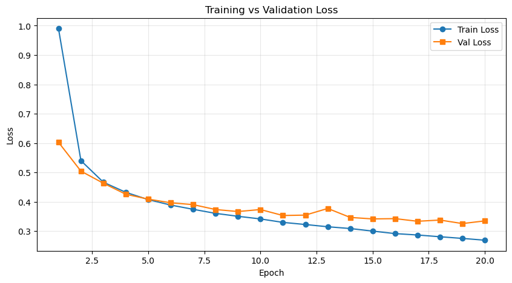

```python
# Loss plot: shows training progress and validation convergence
plt.figure(figsize=(10, 5))
epochs = range(1, len(train_losses) + 1)
plt.plot(epochs, train_losses, label='Train Loss', marker='o')
plt.plot(epochs, val_losses, label='Val Loss', marker='s')
plt.xlabel('Epoch')
plt.ylabel('Loss')
plt.title('Training vs Validation Loss')
plt.legend()
plt.grid(True, alpha=0.3)
plt.show()
```

### 4.7 Loss Curve Analysis

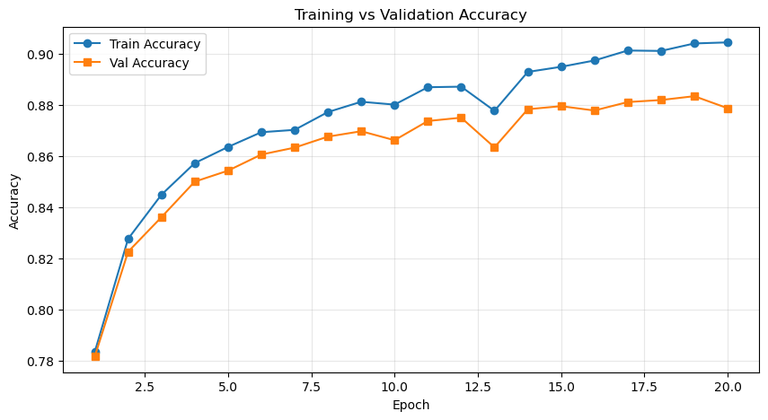

```python
# Accuracy plot: more intuitive interpretation than loss
plt.figure(figsize=(10, 5))
epochs = range(1, len(train_accs) + 1)
plt.plot(epochs, train_accs, label='Train Accuracy', marker='o')
plt.plot(epochs, val_accs, label='Val Accuracy', marker='s')
plt.xlabel('Epoch')
plt.ylabel('Accuracy')
plt.title('Training vs Validation Accuracy')
plt.legend()
plt.grid(True, alpha=0.3)
# Gap between curves shows degree of overfitting
plt.show()
```

**Key observations:**

## 5. Results & Validation Error

```python
# Extract final validation metrics (required for summative report)
final_val_acc = val_accs[-1]
final_val_error = 1.0 - final_val_acc

print(f"Final validation accuracy: {final_val_acc:.4f}")
print(f"Final validation error: {final_val_error:.4f}")

# Overfitting indicator: if gap is large, model is overfitting
final_train_acc = train_accs[-1]
overfitting_gap = final_train_acc - final_val_acc
print(f"\nFinal train accuracy: {final_train_acc:.4f}")
print(f"Overfitting gap (train - val): {overfitting_gap:.4f}")

# Additional diagnostics to support written analysis
peak_val_acc = max(val_accs)
peak_epoch = val_accs.index(peak_val_acc) + 1
min_val_loss = min(val_losses)
minloss_epoch = val_losses.index(min_val_loss) + 1
print(f"\nPeak validation accuracy: {peak_val_acc:.4f} at epoch {peak_epoch}")
print(f"Minimum validation loss: {min_val_loss:.4f} at epoch {minloss_epoch}")

# Print first/last few values for quick inspection
print(f"\nVal accuracy (first 5): {val_accs[:5]}")
print(f"Val accuracy (last 5): {val_accs[-5:]}")
print(f"Train accuracy (last 5): {train_accs[-5:]}")
print(f"Val losses (first 5): {val_losses[:5]}")
print(f"Val losses (last 5): {val_losses[-5:]}")
```

```
Final validation accuracy: 0.8788
Final validation error: 0.1212

Final train accuracy: 0.9045
Overfitting gap (train - val): 0.0257

Peak validation accuracy: 0.8835 at epoch 19
Minimum validation loss: 0.3256 at epoch 19

Val accuracy (first 5): [0.7818, 0.8227, 0.8362, 0.8501, 0.8544]
Val accuracy (last 5): [0.8779, 0.8812, 0.882, 0.8835, 0.8788]
Train accuracy (last 5): [0.89744, 0.90134, 0.90118, 0.9041, 0.90452]
Val losses (first 5): [0.6027496118545532, 0.5043068091392517, 0.4631046979904175, 0.4255266887664795, 0.4088410354614258]
Val losses (last 5): [0.34239259185791016, 0.3333961531162262, 0.3375692126512527, 0.32557853314876556, 0.3347448448777199]
```

## 6. Initial Observations (Baseline Model)

### Baseline Performance

Use the values printed in the previous results cell (`final_val_acc`, `final_val_error`, and overfitting gap) as the baseline summary for this run.

### Interpretation

1. This provides a defensible baseline for a fully connected MLP on FashionMNIST.
2. Compare train vs validation accuracy to assess the generalisation gap (overfitting severity).
3. Use the loss/accuracy curves to justify follow-up changes such as regularisation, optimisation tuning, or model-selection rules.

## 7. Model Variants (Motivated Experiments)

From the baseline run, we observe a **generalisation gap** (TrainAcc > ValAcc) and possible **validation-loss oscillations** after early epochs.  
This suggests the model can fit the training data and may benefit from **regularisation** and/or improved optimisation.

This notebook explores variants in the following order:

1. **Dropout** (single run and dropout-rate sweep)
2. **Weight decay (L2)** sweep
3. **Learning-rate** sweep
4. **BatchNorm** variants
5. **Early stopping / model selection** by validation loss
6. **Final improvement** with augmentation + label smoothing

### 7.1 Helper: concise run summary

We summarise each run by:

- final validation accuracy / error
- peak validation accuracy (best epoch by accuracy)
- generalisation gap at the end (TrainAcc − ValAcc)

```python
def summarize_run(name, train_losses, val_losses, train_accs, val_accs):
    final_train_acc = train_accs[-1]
    final_val_acc = val_accs[-1]
    final_val_error = 1 - final_val_acc

    peak_val_acc = max(val_accs)
    peak_epoch = val_accs.index(peak_val_acc) + 1

    gap = final_train_acc - final_val_acc

    print(f"\n{name}")
    print(f"  Final val acc: {final_val_acc:.4f}  | Final val error: {final_val_error:.4f}")
    print(f"  Peak  val acc: {peak_val_acc:.4f}  (epoch {peak_epoch})")
    print(f"  Overfit gap:   {gap:.4f}  (final TrainAcc - ValAcc)")
```

### 7.2 Variant 1: Dropout (target: reduce overfitting)

Baseline shows a noticeable generalisation gap.  
Dropout is a standard regulariser for MLPs: it reduces reliance on any single hidden unit and often improves validation performance.

```python
import torch.nn as nn

class DeepMLP_Dropout(nn.Module):
    def __init__(self, p=0.2):
        super().__init__()
        self.net = nn.Sequential(
            nn.Flatten(),

            nn.Linear(28*28, 512),
            nn.ReLU(),
            nn.Dropout(p),

            nn.Linear(512, 256),
            nn.ReLU(),
            nn.Dropout(p),

            nn.Linear(256, 128),
            nn.ReLU(),
            nn.Dropout(p),

            nn.Linear(128, 10)
        )

    def forward(self, x):
        return self.net(x)

model_do = DeepMLP_Dropout(p=0.2).to(device)

do_train_losses, do_val_losses, do_train_accs, do_val_accs = train(
    model_do,
    train_data=fashion_train,
    val_data=fashion_val,
    batch_size=128,
    num_epochs=20,
    lr=0.0001,      # Baseline learning rate
    weight_decay=0.0
)

summarize_run("Dropout p=0.2", do_train_losses, do_val_losses, do_train_accs, do_val_accs)
```

```
Dropout p=0.2
  Final val acc: 0.8898  | Final val error: 0.1102
  Peak  val acc: 0.8898  (epoch 20)
  Overfit gap:   0.0237  (final TrainAcc - ValAcc)
```

### 7.3 Variant: Dropout (p = 0.2)

**Motivation.** The baseline MLP showed a generalisation gap (TrainAcc > ValAcc), suggesting overfitting. Dropout is a standard MLP regulariser that reduces co-adaptation by randomly zeroing hidden activations during training.

- final validation accuracy / validation error
- peak validation accuracy and epoch
- final overfitting gap (TrainAcc − ValAcc)

**Interpretation guide.**

- If the train/validation gap shrinks relative to baseline, dropout is helping regularisation.
- If peak validation accuracy occurs well before the final epoch, use that to motivate early stopping or additional tuning.
- If validation loss is noisy, test weight decay and/or learning-rate tuning next.

### 7.4 Variant: Dropout Rate Sweep (p ∈ {0.1, 0.2, 0.3})

```python
# Dropout sweep: keep everything else fixed for a clean comparison
dropout_ps = [0.1, 0.2, 0.3]

dropout_results = {}

for p in dropout_ps:
    print("\n" + "-"*70)
    print(f"Running dropout p = {p}")

    model_do = DeepMLP_Dropout(p=p).to(device)  # same class as your dropout variant

    trL, vaL, trA, vaA = train(
        model_do,
        train_data=fashion_train,
        val_data=fashion_val,
        batch_size=128,
        num_epochs=20,
        lr=0.0001,      # Baseline learning rate
        weight_decay=0.0
    )

    dropout_results[p] = (trL, vaL, trA, vaA)
    summarize_run(f"Dropout p={p}", trL, vaL, trA, vaA)
```

```
----------------------------------------------------------------------
Running dropout p = 0.1

Dropout p=0.1
  Final val acc: 0.8878  | Final val error: 0.1122
  Peak  val acc: 0.8878  (epoch 20)
  Overfit gap:   0.0259  (final TrainAcc - ValAcc)

----------------------------------------------------------------------
Running dropout p = 0.2

Dropout p=0.2
  Final val acc: 0.8884  | Final val error: 0.1116
  Peak  val acc: 0.8888  (epoch 19)
  Overfit gap:   0.0230  (final TrainAcc - ValAcc)

----------------------------------------------------------------------
Running dropout p = 0.3

Dropout p=0.3
  Final val acc: 0.8878  | Final val error: 0.1122
  Peak  val acc: 0.8878  (epoch 20)
  Overfit gap:   0.0196  (final TrainAcc - ValAcc)
```

### 7.5 Compare Dropout Variants (Validation Loss Curves)

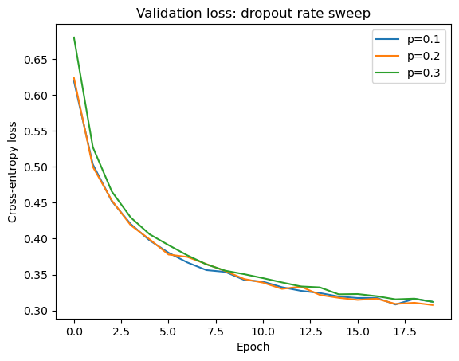

```python
import matplotlib.pyplot as plt

plt.title("Validation loss: dropout rate sweep")
for p in dropout_ps:
    plt.plot(dropout_results[p][1], label=f"p={p}")

plt.xlabel("Epoch")
plt.ylabel("Cross-entropy loss")
plt.legend(loc="best")
plt.show()
```

### 7.6 Select Best Dropout by Peak Validation Accuracy

```python
best_p = max(dropout_ps, key=lambda p: max(dropout_results[p][3]))
best_peak_acc = max(dropout_results[best_p][3])
best_peak_epoch = dropout_results[best_p][3].index(best_peak_acc) + 1
best_peak_error = 1 - best_peak_acc

print(f"Best dropout p = {best_p}")
print(f"Peak validation accuracy = {best_peak_acc:.4f} (epoch {best_peak_epoch})")
print(f"Validation error at peak = {best_peak_error:.4f}")
```

```
Best dropout p = 0.2
Peak validation accuracy = 0.8888 (epoch 19)
Validation error at peak = 0.1112
```

### 7.7 Next Variant: Weight Decay Sweep (dropout p = 0.2 fixed)

**Motivation.** The dropout sweep shows similar validation-loss curves across p ∈ {0.1, 0.2, 0.3}, with p=0.2 marginally best.  
However, validation loss still oscillates and the model shows mild overfitting (TrainAcc > ValAcc).  
We therefore fix dropout at p=0.2 and tune **weight decay (L2 regularisation)** to improve generalisation and training stability.

```python
wd_grid = [1e-4, 1e-3, 1e-2, 5e-2]
# Establish a grid of weight decay values to test, keeping dropout fixed at p=0.2 for a clean comparison.
wd_do_results = {}
wd_summary = []  # (wd, peak_val_acc, peak_epoch, peak_val_error)

for wd in wd_grid:
    print("\n" + "="*70)
    print(f"Dropout p=0.2 | weight_decay = {wd}")

    model = DeepMLP_Dropout(p=0.2).to(device)

    trL, vaL, trA, vaA = train(
        model,
        train_data=fashion_train,
        val_data=fashion_val,
        batch_size=128,
        num_epochs=20,
        lr=0.0001,      # Baseline learning rate
        weight_decay=wd
    )

    peak_val_acc = max(vaA)
    peak_epoch = vaA.index(peak_val_acc) + 1
    peak_val_error = 1 - peak_val_acc

    wd_do_results[wd] = (trL, vaL, trA, vaA)
    wd_summary.append((wd, peak_val_acc, peak_epoch, peak_val_error))

    print(f"wd={wd} | peak val acc={peak_val_acc:.4f} (epoch {peak_epoch}) | peak val error={peak_val_error:.4f}")

best_wd, best_acc, best_epoch, best_err = max(wd_summary, key=lambda t: t[1])
print("\n" + "-"*70)
print(f"Best weight_decay = {best_wd}")
print(f"Peak validation accuracy = {best_acc:.4f} (epoch {best_epoch})")
print(f"Validation error at peak = {best_err:.4f}")
```

```
======================================================================
Dropout p=0.2 | weight_decay = 0.0001
wd=0.0001 | peak val acc=0.8894 (epoch 19) | peak val error=0.1106

======================================================================
Dropout p=0.2 | weight_decay = 0.001
wd=0.001 | peak val acc=0.8878 (epoch 18) | peak val error=0.1122

======================================================================
Dropout p=0.2 | weight_decay = 0.01
wd=0.01 | peak val acc=0.8887 (epoch 20) | peak val error=0.1113

======================================================================
Dropout p=0.2 | weight_decay = 0.05
wd=0.05 | peak val acc=0.8893 (epoch 20) | peak val error=0.1107

----------------------------------------------------------------------
Best weight_decay = 0.0001
Peak validation accuracy = 0.8894 (epoch 19)
Validation error at peak = 0.1106
```

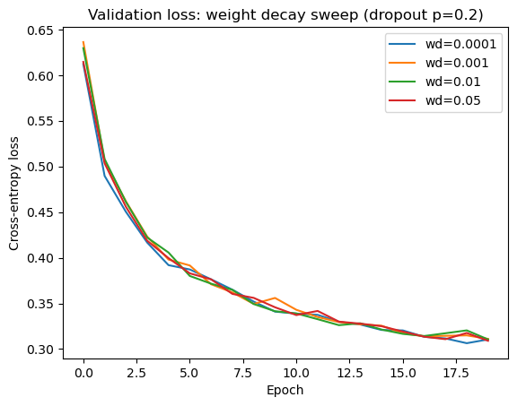

```python
plt.title("Validation loss: weight decay sweep (dropout p=0.2)")
for wd in wd_grid:
    plt.plot(wd_do_results[wd][1], label=f"wd={wd}")
plt.xlabel("Epoch")
plt.ylabel("Cross-entropy loss")
plt.legend(loc="best")
plt.show()
```

### 7.8 Next Variant: Learning-Rate Sweep (selected regularisation setting)

**Motivation.** After choosing a regularisation configuration from the previous sweep(s), we tune the learning rate because it strongly affects optimisation stability and final validation performance.  
We test a small grid around the baseline learning rate and compare peak validation accuracy plus validation-loss curves.

```python
lr_grid = [0.0003, 0.0001, 0.0002]

lr_results = []
for lr in lr_grid:
    print("\n" + "="*70)
    print(f"dropout p=0.2 | wd=0.0001 | lr={lr}")

    model = DeepMLP_Dropout(p=0.2).to(device)

    trL, vaL, trA, vaA = train(
        model,
        train_data=fashion_train,
        val_data=fashion_val,
        batch_size=128,
        num_epochs=20,
        lr=lr,
        weight_decay=0.0001
    )

    peak_val_acc = max(vaA)
    peak_epoch = vaA.index(peak_val_acc) + 1
    peak_val_error = 1 - peak_val_acc

    lr_results.append((lr, peak_val_acc, peak_epoch, peak_val_error, trL, vaL, trA, vaA))
    print(f"lr={lr} | peak val acc={peak_val_acc:.4f} (epoch {peak_epoch}) | peak val error={peak_val_error:.4f}")

best_lr, best_acc, best_epoch, best_err, *_ = max(lr_results, key=lambda t: t[1])
print("\n" + "-"*70)
print(f"Best lr = {best_lr}")
print(f"Peak validation accuracy = {best_acc:.4f} (epoch {best_epoch})")
print(f"Validation error at peak = {best_err:.4f}")
```

```
======================================================================
dropout p=0.2 | wd=0.0001 | lr=0.0003
lr=0.0003 | peak val acc=0.8982 (epoch 18) | peak val error=0.1018

======================================================================
dropout p=0.2 | wd=0.0001 | lr=0.0001
lr=0.0001 | peak val acc=0.8887 (epoch 16) | peak val error=0.1113

======================================================================
dropout p=0.2 | wd=0.0001 | lr=0.0002
lr=0.0002 | peak val acc=0.8966 (epoch 20) | peak val error=0.1034

----------------------------------------------------------------------
Best lr = 0.0003
Peak validation accuracy = 0.8982 (epoch 18)
Validation error at peak = 0.1018
```

[figure not shown]

```python
plt.title("Validation loss: LR sweep (dropout p=0.2, wd=1e-3)")
for lr, _, _, _, _, vaL, _, _ in lr_results:
    plt.plot(vaL, label=f"lr={lr}")
plt.xlabel("Epoch")
plt.ylabel("Cross-entropy loss")
plt.legend(loc="best")
plt.show()
```

### 7.9 Next Variant: Batch Normalisation (selected regularisation setting)

**Motivation.** If tuning dropout/weight decay/learning rate does not improve peak validation accuracy enough, Batch Normalisation is a reasonable next test.  
BatchNorm can stabilise optimisation by normalising hidden-layer activations, which may improve convergence and generalisation in deep MLPs.

We therefore keep the selected settings from earlier sweeps and add BatchNorm layers for comparison.

```python
class DeepMLP_BN_Dropout(nn.Module):
    def __init__(self, p=0.2):
        super().__init__()
        self.net = nn.Sequential(
            nn.Flatten(),

            nn.Linear(28*28, 512),
            nn.BatchNorm1d(512),
            nn.ReLU(),
            nn.Dropout(p),

            nn.Linear(512, 256),
            nn.BatchNorm1d(256),
            nn.ReLU(),
            nn.Dropout(p),

            nn.Linear(256, 128),
            nn.BatchNorm1d(128),
            nn.ReLU(),
            nn.Dropout(p),

            nn.Linear(128, 10)
        )

    def forward(self, x):
        return self.net(x)

model_bn = DeepMLP_BN_Dropout(p=0.2).to(device)

bn_train_losses, bn_val_losses, bn_train_accs, bn_val_accs = train(
    model_bn,
    train_data=fashion_train,
    val_data=fashion_val,
    batch_size=128,
    num_epochs=20,
    lr=0.0003,
    weight_decay=0.0001
)

summarize_run("BatchNorm + Dropout p=0.2 (wd=0.0001)", bn_train_losses, bn_val_losses, bn_train_accs, bn_val_accs)
```

```
BatchNorm + Dropout p=0.2 (wd=0.0001)
  Final val acc: 0.8898  | Final val error: 0.1102
  Peak  val acc: 0.8972  (epoch 17)
  Overfit gap:   0.0628  (final TrainAcc - ValAcc)
```

### 7.10 Variant: BatchNorm *without* Dropout

**Motivation.** The BatchNorm + Dropout model performed worse than the best regularised MLP.  
A plausible explanation is that **BatchNorm and Dropout interact poorly** in this setting (Dropout changes activation distributions that BatchNorm then normalises).  
We therefore test BatchNorm **without** Dropout, keeping other settings fixed, to isolate whether BatchNorm alone helps.

```python
import torch.nn as nn

class DeepMLP_BN_NoDropout(nn.Module):
    def __init__(self):
        super().__init__()
        self.net = nn.Sequential(
            nn.Flatten(),

            nn.Linear(28*28, 512),
            nn.BatchNorm1d(512),
            nn.ReLU(),

            nn.Linear(512, 256),
            nn.BatchNorm1d(256),
            nn.ReLU(),

            nn.Linear(256, 128),
            nn.BatchNorm1d(128),
            nn.ReLU(),

            nn.Linear(128, 10)
        )

    def forward(self, x):
        return self.net(x)

model_bn_nodo = DeepMLP_BN_NoDropout().to(device)

bnnd_train_losses, bnnd_val_losses, bnnd_train_accs, bnnd_val_accs = train(
    model_bn_nodo,
    train_data=fashion_train,
    val_data=fashion_val,
    batch_size=128,
    num_epochs=20,
    lr=0.0003,
    weight_decay=0.001
)

summarize_run("BatchNorm (no dropout), wd=0.0001", bnnd_train_losses, bnnd_val_losses, bnnd_train_accs, bnnd_val_accs)
```

[output not shown]

### 7.11 Model Selection via Early Stopping (Validation Loss)

Rather than fixing the number of epochs, we train up to a maximum budget and **select the checkpoint with the lowest validation loss**. This reduces overfitting and provides a principled selection rule for the final reported validation error.

```python
# Final candidate config (edit wd if your best differs)
BEST_WD = 0.0001
LR = 1e-3
BATCH_SIZE = 128
MAX_EPOCHS = 60

# Train for a larger epoch budget, then pick best epoch by min validation loss
model_final = DeepMLP().to(device)

train_losses, val_losses, train_accs, val_accs = train(
    model_final,
    train_data=fashion_train,
    val_data=fashion_val,
    batch_size=BATCH_SIZE,
    num_epochs=MAX_EPOCHS,
    lr=LR,
    weight_decay=BEST_WD
)

best_epoch = min(range(len(val_losses)), key=lambda i: val_losses[i])
best_val_loss = val_losses[best_epoch]
best_val_acc = val_accs[best_epoch]
best_val_error = 1 - best_val_acc

print("\nEarly-stopping selection (min val loss):")
print(f"Best epoch: {best_epoch+1}")
print(f"Val loss:   {best_val_loss:.4f}")
print(f"Val acc:    {best_val_acc:.4f}")
print(f"Val error:  {best_val_error:.4f}")
```

```
Early-stopping selection (min val loss):
Best epoch: 11
Val loss:   0.3115
Val acc:    0.8908
Val error:  0.1092
```

### 7.12 Loss Curves (Train vs Validation)

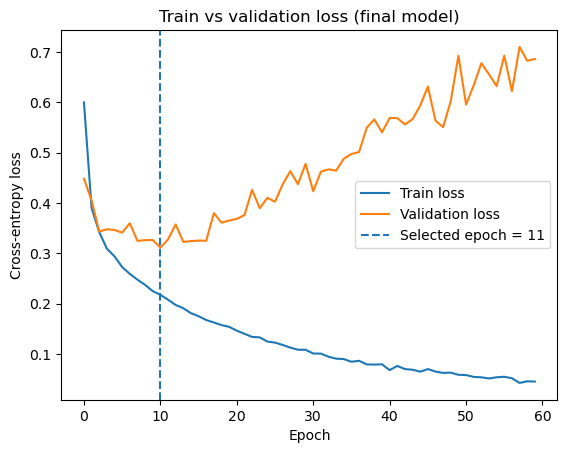

```python
plt.title("Train vs validation loss (final model)")
plt.plot(train_losses, label="Train loss")
plt.plot(val_losses, label="Validation loss")
plt.axvline(best_epoch, linestyle="--", label=f"Selected epoch = {best_epoch+1}")
plt.xlabel("Epoch")
plt.ylabel("Cross-entropy loss")
plt.legend(loc="best")
plt.show()
```

### 7.13 Add Mild Data Augmentation + Label Smoothing (Final Improvement)

**Motivation.** The loss curves show classic overfitting: training loss continues to fall while validation loss reaches a minimum early and then rises.  
We apply two standard generalisation techniques without changing the model family:

1. **Label smoothing** in cross-entropy to reduce over-confident predictions.
2. **Random padded crops** to encourage robustness to small translations.

**Implementation note.** Augmentations must be applied on-the-fly via dataset transforms, so we use `torch.utils.data.Subset` instead of converting the dataset to a Python list.

```python
import torch
from torch.utils.data import Subset
from torchvision import datasets, transforms

# ---- transforms (train has augmentation; val/test do not) ----
transform_train = transforms.Compose([
    transforms.RandomCrop(28, padding=4),   # mild augmentation
    transforms.ToTensor(),
    transforms.Normalize((0.5,), (0.5,)),
])

transform_eval = transforms.Compose([
    transforms.ToTensor(),
    transforms.Normalize((0.5,), (0.5,)),
])

data_dir = "./data"

# Two train datasets so augmentation is train-only (on-the-fly)
train_full_aug  = datasets.FashionMNIST(data_dir, train=True,  download=True, transform=transform_train)
train_full_eval = datasets.FashionMNIST(data_dir, train=True,  download=True, transform=transform_eval)

# Test set (no augmentation) -- held out (optional to use)
test_data = datasets.FashionMNIST(data_dir, train=False, download=True, transform=transform_eval)

# ---- representative split for speed (allowed) ----
n_train = 40000
n_val   = 10000
assert n_train + n_val <= len(train_full_aug)  # len = 60000

# Reproducible split
try:
    g
except NameError:
    g = torch.Generator().manual_seed(42)

perm = torch.randperm(len(train_full_aug), generator=g)
train_idx = perm[:n_train].tolist()
val_idx   = perm[n_train:n_train + n_val].tolist()

train_data = Subset(train_full_aug, train_idx)     # augmented
val_data   = Subset(train_full_eval, val_idx)      # no augmentation

print("Train/Val/Test sizes:", len(train_data), len(val_data), len(test_data))
```

```
Train/Val/Test sizes: 40000 10000 10000
```

### 7.14 Update Training Loss: CrossEntropy with Label Smoothing

We keep the same training loop, but use `label_smoothing=0.1` in the loss.

```python
import torch.nn as nn
import torch.optim as optim
from torch.utils.data import DataLoader

def train(
    model, train_data, val_data,
    batch_size=128, num_epochs=20, lr=0.0001, weight_decay=0.0001,
    label_smoothing=0.02, # small amount of label smoothing for regularization
    eval_every=5,        # compute accuracies every N epochs
    val_every=1,         # compute val loss every N epochs (use 1 for final report)
    progress_batches=50  # print batch progress on epoch 1 every N batches (None to disable)
):
    criterion = nn.CrossEntropyLoss(label_smoothing=label_smoothing)
    optimizer = optim.AdamW(model.parameters(), lr=lr, weight_decay=weight_decay)

    # Keep this Mac/MPS-friendly + deterministic
    train_loader = DataLoader(train_data, batch_size=batch_size, shuffle=True, generator=g, num_workers=0)

    train_losses, val_losses = [], []
    train_accs, val_accs = [], []

    for epoch in range(num_epochs):
        model.train()
        running_loss = 0.0

        for b, (imgs, labels) in enumerate(train_loader, start=1):
            imgs, labels = imgs.to(device), labels.to(device)

            out = model(imgs)
            loss = criterion(out, labels)

            optimizer.zero_grad()
            loss.backward()
            optimizer.step()

            running_loss += loss.item() * labels.size(0)

            # visibility so it never feels "stuck"
            if (epoch == 0) and (progress_batches is not None) and (b % progress_batches == 0):
                print(f"  [epoch 1] batch {b} / ~{len(train_loader)} | batch loss {loss.item():.4f}")

        avg_train_loss = running_loss / len(train_data)

        # val loss (optionally less frequent while experimenting)
        if (epoch + 1) % val_every == 0:
            avg_val_loss = get_avg_loss(model, val_data, criterion, batch_size=batch_size)
        else:
            avg_val_loss = float("nan")

        # accuracies (expensive; do less often)
        if (epoch + 1) % eval_every == 0 or epoch == 0 or epoch == num_epochs - 1:
            train_acc = get_accuracy(model, train_data, batch_size=batch_size)
            val_acc   = get_accuracy(model, val_data, batch_size=batch_size)
        else:
            train_acc = float("nan")
            val_acc   = float("nan")

        train_losses.append(avg_train_loss)
        val_losses.append(avg_val_loss)
        train_accs.append(train_acc)
        val_accs.append(val_acc)

        # nice ST311-style print
        msg = f"Epoch {epoch+1}/{num_epochs} | TrainLoss {avg_train_loss:.4f}"
        if not (avg_val_loss != avg_val_loss):  # not NaN
            msg += f" | ValLoss {avg_val_loss:.4f}"
        if not (train_acc != train_acc):        # not NaN
            msg += f" | TrainAcc {train_acc:.4f} | ValAcc {val_acc:.4f}"
        print(msg)

    return train_losses, val_losses, train_accs, val_accs
```

We train up to a maximum epoch budget and select the checkpoint by **minimum validation loss**.

```python
# Example hyperparams for the final variant
batch_size = 256
num_epochs = 40
lr = 0.0001
weight_decay = 0.0001
label_smoothing = 0.1

# Make sure model is re-initialised AFTER seeding (as you’ve been doing)
model = model.to(device)

train_losses, val_losses, train_accs, val_accs = train(
    model, train_data, val_data,
    batch_size=batch_size,
    num_epochs=num_epochs,
    lr=lr,
    weight_decay=weight_decay,
    label_smoothing=label_smoothing,
    eval_every=5,
    val_every=1,          # for final run keep 1 so loss curve is complete
    progress_batches=25   # so you see it running in epoch 1
)
```

```
  [epoch 1] batch 25 / ~157 | batch loss 1.0612
  [epoch 1] batch 50 / ~157 | batch loss 1.0136
  [epoch 1] batch 75 / ~157 | batch loss 1.0749
  [epoch 1] batch 100 / ~157 | batch loss 1.0592
  [epoch 1] batch 125 / ~157 | batch loss 1.0295
  [epoch 1] batch 150 / ~157 | batch loss 0.9859
```

## 8. Final Comparison / Discussion

This section reproduces baseline and selected final-model runs in a consistent format so the comparison figures and summary metrics are easy to interpret side by side.

### 8.1 Re-running Baseline and Final Model Specs to Produce Figures

This cell reruns the baseline and final configurations to generate comparable figures in one place; it may overwrite in-memory variables such as `train_losses` / `val_losses`.

```
  [epoch 1] batch 50 / ~391 | batch loss 1.7837
  [epoch 1] batch 100 / ~391 | batch loss 1.1473
  [epoch 1] batch 150 / ~391 | batch loss 0.9094
  [epoch 1] batch 200 / ~391 | batch loss 0.8883
  [epoch 1] batch 250 / ~391 | batch loss 0.8293
  [epoch 1] batch 300 / ~391 | batch loss 0.7554
  [epoch 1] batch 350 / ~391 | batch loss 0.7400
  [epoch 1] batch 50 / ~391 | batch loss 1.0857
  [epoch 1] batch 100 / ~391 | batch loss 0.8269
  [epoch 1] batch 150 / ~391 | batch loss 0.7576
  [epoch 1] batch 200 / ~391 | batch loss 0.6750
  [epoch 1] batch 250 / ~391 | batch loss 0.6327
  [epoch 1] batch 300 / ~391 | batch loss 0.6650
  [epoch 1] batch 350 / ~391 | batch loss 0.6327
BASELINE: peak val acc = 0.8859, val error = 0.1141, best epoch = 20
FINAL:    peak val acc = 0.8978, val error = 0.1022, best epoch = 20
```

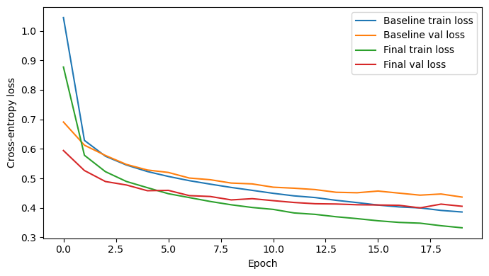

```python
import matplotlib.pyplot as plt

# =========================
# 1) BASELINE (store under distinct names)
# =========================
model_base = DeepMLP().to(device)
base_train_losses, base_val_losses, base_train_accs, base_val_accs = train(
    model_base,
    train_data=fashion_train,
    val_data=fashion_val,
    batch_size=128,
    num_epochs=20,
    lr=1e-4,
    weight_decay=0.0
)

base_best_epoch = 1 + max(range(len(base_val_accs)), key=lambda i: base_val_accs[i])
base_peak_acc = base_val_accs[base_best_epoch - 1]
base_val_err = 1.0 - base_peak_acc

# =========================
# 2) FINAL (selected) (store under distinct names)
# Dropout p=0.2 + weight decay 1e-4 + LR 3e-4
# =========================
model_final = DeepMLP_Dropout(p=0.2).to(device)
final_train_losses, final_val_losses, final_train_accs, final_val_accs = train(
    model_final,
    train_data=fashion_train,
    val_data=fashion_val,
    batch_size=128,
    num_epochs=20,
    lr=3e-4,
    weight_decay=1e-4
)

final_best_epoch = 1 + max(range(len(final_val_accs)), key=lambda i: final_val_accs[i])
final_peak_acc = final_val_accs[final_best_epoch - 1]
final_val_err = 1.0 - final_peak_acc

# =========================
# 3) Print headline numbers (for write-up)
# =========================
print(f"BASELINE: peak val acc = {base_peak_acc:.4f}, val error = {base_val_err:.4f}, best epoch = {base_best_epoch}")
print(f"FINAL:    peak val acc = {final_peak_acc:.4f}, val error = {final_val_err:.4f}, best epoch = {final_best_epoch}")

# =========================
# 4) FIGURE 1: training + validation loss over epochs (baseline vs final)
# =========================
plt.figure(figsize=(7,4))
plt.plot(base_train_losses, label="Baseline train loss")
plt.plot(base_val_losses,   label="Baseline val loss")
plt.plot(final_train_losses, label="Final train loss")
plt.plot(final_val_losses,   label="Final val loss")
plt.xlabel("Epoch")
plt.ylabel("Cross-entropy loss")
plt.legend()
plt.tight_layout()
plt.savefig("fig_loss_baseline_vs_final.pdf")
```